# HW02

```r
library(haven)
library(dplyr)
library(haven)
library(tidyverse)
library(lmtest)
library(sandwich)
library(grf)
library(glmnet)
```

```r
library(splines)
library(ggplot2)
library(reshape2)
```

## Part I: Evaluating Treatment Heterogeneity

### Question 1

```r
library(grf)
trueATE_1 = rep(0,20)
trueATE_2 = rep(0,20)
trueATE_3 = rep(0,20)
trueATE_4 = rep(0,20)
avgCATE_1 = rep(0,20)
avgCATE_2 = rep(0,20)
avgCATE_3 = rep(0,20)
avgCATE_4 = rep(0,20)
avgAIPW_1 = rep(0,20)
avgAIPW_2 = rep(0,20)
avgAIPW_3 = rep(0,20)
avgAIPW_4 = rep(0,20)

for (i in 1:20) {
  #simulate data
  set.seed(i+1)
  n = 8000
  p = 6
  taufn = function(x){1/3}
  X = matrix(rnorm(n * p), n, p)
  tau = apply(X, 1, taufn)
  W = rbinom(n, 1, 1/(1 + exp(-X[,1] / 2)))
  Y = pmax(0, X[,1] / 2 + X[,2]) + W * tau + rnorm(n)

  #Train a causal forest and compute(out-of-bag) CATE estimates on the training set
  c.forest <- causal_forest(X, Y, W)

  # Predict on out-of-bag training samples.
  c.pred <- predict(c.forest)

  #dataframe, then break into quartiles
  simu_data <- data.frame(Y, X, W, tau, c.pred)
  quartiles <- quantile(simu_data$predictions, prob=seq(from=0,to=1,by=0.25),na.rm=TRUE)
  simu_data$quartiles <- cut(simu_data$predictions, breaks = quartiles, labels = 1:4, include.lowest = TRUE)

  #appending many treatment effects
  trueATE_1[i] = mean(simu_data[which(simu_data$W==1 & simu_data$quartiles == '1'), 'tau'])
  trueATE_2[i] = mean(simu_data[which(simu_data$W==1 & simu_data$quartiles == '1'), 'tau'])
  trueATE_3[i] = mean(simu_data[which(simu_data$W==1 & simu_data$quartiles == '1'), 'tau'])
  trueATE_4[i] = mean(simu_data[which(simu_data$W==1 & simu_data$quartiles == '1'), 'tau'])
  #estimated CATE by causal forest
  avgCATE_1[i] = mean(simu_data[which(simu_data$W==1 & simu_data$quartiles == 1), 'predictions'])
  avgCATE_2[i] = mean(simu_data[which(simu_data$W==1 & simu_data$quartiles == 2), 'predictions'])
  avgCATE_3[i] = mean(simu_data[which(simu_data$W==1 & simu_data$quartiles == 3), 'predictions'])
  avgCATE_4[i] = mean(simu_data[which(simu_data$W==1 & simu_data$quartiles == 4), 'predictions'])

}
# a) True ATE per quartile
print(mean(trueATE_1))
```

```
## [1] 0.3333333
```

```r
print(mean(trueATE_2))
```

```
## [1] 0.3333333
```

```r
print(mean(trueATE_3))
```

```
## [1] 0.3333333
```

```r
print(mean(trueATE_4))
```

```
## [1] 0.3333333
```

```r
# b) correlation between quarter index and estimated CATE?
cor.test(c(1,2,3,4), c(mean(avgCATE_1),mean(avgCATE_2),mean(avgCATE_3),mean(avgCATE_4)) , method="pearson")
```

```
##
##  Pearson's product-moment correlation
##
## data:  c(1, 2, 3, 4) and c(mean(avgCATE_1), mean(avgCATE_2), mean(avgCATE_3), mean(avgCATE_4))
## t = 19.353, df = 2, p-value = 0.002659
## alternative hypothesis: true correlation is not equal to 0
## 95 percent confidence interval:
##  0.8742335 0.9999472
## sample estimates:
##       cor
## 0.9973406
```

```r
#AIPW
AIPW1 = average_treatment_effect(c.forest, method = 'AIPW', subset = simu_data$quartiles == 1)
AIPW2 = average_treatment_effect(c.forest, method = 'AIPW', subset = simu_data$quartiles == 2)
AIPW3 = average_treatment_effect(c.forest, method = 'AIPW', subset = simu_data$quartiles == 3)
AIPW4 = average_treatment_effect(c.forest, method = 'AIPW', subset = simu_data$quartiles == 4)

# c) correlation quarter index and estimated CATE using AIPW?
cor.test(c(1,2,3,4), c(AIPW1[1],AIPW2[1],AIPW3[1],AIPW4[1]), method="pearson")
```

```
##
##  Pearson's product-moment correlation
##
## data:  c(1, 2, 3, 4) and c(AIPW1[1], AIPW2[1], AIPW3[1], AIPW4[1])
## t = 0.92244, df = 2, p-value = 0.4537
## alternative hypothesis: true correlation is not equal to 0
## 95 percent confidence interval:
##  -0.8733057  0.9884241
## sample estimates:
##       cor
## 0.5463214
```

```r
# c) Magnitude of standard errors
print(AIPW1[2])
```

```
##    std.err
## 0.04435396
```

```r
print(AIPW2[2])
```

```
##    std.err
## 0.04611045
```

```r
print(AIPW3[2])
```

```
##    std.err
## 0.04577495
```

```r
print(AIPW4[2])
```

```
##    std.err
## 0.04596662
```

```r
#Question 3
test_calibration(c.forest)
```

```
##
## Best linear fit using forest predictions (on held-out data)
## as well as the mean forest prediction as regressors, along
## with one-sided heteroskedasticity-robust (HC3) SEs:
##
##                                Estimate Std. Error t value  Pr(>t)
## mean.forest.prediction         1.001698   0.070662 14.1760 < 2e-16 ***
## differential.forest.prediction 0.459054   0.298806  1.5363 0.06225 .
## ---
## Signif. codes:  0 '***' 0.001 '**' 0.01 '*' 0.05 '.' 0.1 ' ' 1
```

## Interpretation

### a) The true tau in each quartile is 1/3.

### b) There is an extremely strong correlation with quartile index and estimated CATE in each quartile because this is how the quartile index was generated (by ascending out-of-bag CATE).

### c) There is no statistically significant correlation found with quartile index and estiamted per-quartile CATE using AIPW. The magnitude of the standard error is extremely small compared to the estimation (0.333).

### Question 2

```r
library(grf)
trueATE_1 = rep(0,20)
trueATE_2 = rep(0,20)
trueATE_3 = rep(0,20)
trueATE_4 = rep(0,20)
avgCATE_1 = rep(0,20)
avgCATE_2 = rep(0,20)
avgCATE_3 = rep(0,20)
avgCATE_4 = rep(0,20)
avgAIPW_1 = rep(0,20)
avgAIPW_2 = rep(0,20)
avgAIPW_3 = rep(0,20)
avgAIPW_4 = rep(0,20)

for (i in 1:20) {
  #simulate data
  set.seed(i+1)
  n = 8000
  p = 6
  taufn = function(x) { 1 / (1 + exp(-x[2]/2)) }
  X = matrix(rnorm(n * p), n, p)
  tau = apply(X, 1, taufn)
  W = rbinom(n, 1, 1/(1 + exp(-X[,1] / 2)))
  Y = pmax(0, X[,1] / 2 + X[,2]) + W * tau + rnorm(n)

  #Train a causal forest and compute(out-of-bag) CATE estimates on the training set
  c.forest <- causal_forest(X, Y, W)

  # Predict on out-of-bag training samples.
  c.pred <- predict(c.forest)

  #dataframe, then break into quartiles
  simu_data <- data.frame(Y, X, W, tau, c.pred)
  quartiles <- quantile(simu_data$predictions, prob=seq(from=0,to=1,by=0.25),na.rm=TRUE)
  simu_data$quartiles <- cut(simu_data$predictions, breaks = quartiles, labels = 1:4, include.lowest = TRUE)

  #appending many treatment effects
  trueATE_1[i] = mean(simu_data[which(simu_data$W==1 & simu_data$quartiles == '1'), 'tau'])
  trueATE_2[i] = mean(simu_data[which(simu_data$W==1 & simu_data$quartiles == '1'), 'tau'])
  trueATE_3[i] = mean(simu_data[which(simu_data$W==1 & simu_data$quartiles == '1'), 'tau'])
  trueATE_4[i] = mean(simu_data[which(simu_data$W==1 & simu_data$quartiles == '1'), 'tau'])
  #estimated CATE by causal forest
  avgCATE_1[i] = mean(simu_data[which(simu_data$W==1 & simu_data$quartiles == 1), 'predictions'])
  avgCATE_2[i] = mean(simu_data[which(simu_data$W==1 & simu_data$quartiles == 2), 'predictions'])
  avgCATE_3[i] = mean(simu_data[which(simu_data$W==1 & simu_data$quartiles == 3), 'predictions'])
  avgCATE_4[i] = mean(simu_data[which(simu_data$W==1 & simu_data$quartiles == 4), 'predictions'])

}
# a) True ATE per quartile
print(mean(trueATE_1))
```

```
## [1] 0.3858915
```

```r
print(mean(trueATE_2))
```

```
## [1] 0.3858915
```

```r
print(mean(trueATE_3))
```

```
## [1] 0.3858915
```

```r
print(mean(trueATE_4))
```

```
## [1] 0.3858915
```

```r
# b) correlation between quarter index and estimated CATE?
cor.test(c(1,2,3,4), c(mean(avgCATE_1),mean(avgCATE_2),mean(avgCATE_3),mean(avgCATE_4)) , method="pearson")
```

```
##
##  Pearson's product-moment correlation
##
## data:  c(1, 2, 3, 4) and c(mean(avgCATE_1), mean(avgCATE_2), mean(avgCATE_3), mean(avgCATE_4))
## t = 22.093, df = 2, p-value = 0.002042
## alternative hypothesis: true correlation is not equal to 0
## 95 percent confidence interval:
##  0.9020084 0.9999594
## sample estimates:
##       cor
## 0.9979575
```

```r
#AIPW
AIPW1 = average_treatment_effect(c.forest, method = 'AIPW', subset = simu_data$quartiles == 1)
AIPW2 = average_treatment_effect(c.forest, method = 'AIPW', subset = simu_data$quartiles == 2)
AIPW3 = average_treatment_effect(c.forest, method = 'AIPW', subset = simu_data$quartiles == 3)
AIPW4 = average_treatment_effect(c.forest, method = 'AIPW', subset = simu_data$quartiles == 4)

# c) correlation quarter index and estimated CATE using AIPW?
cor.test(c(1,2,3,4), c(AIPW1[1],AIPW2[1],AIPW3[1],AIPW4[1]), method="pearson")
```

```
##
##  Pearson's product-moment correlation
##
## data:  c(1, 2, 3, 4) and c(AIPW1[1], AIPW2[1], AIPW3[1], AIPW4[1])
## t = 2.2999, df = 2, p-value = 0.1482
## alternative hypothesis: true correlation is not equal to 0
## 95 percent confidence interval:
##  -0.6025517  0.9968299
## sample estimates:
##       cor
## 0.8518397
```

```r
# c) Magnitude of standard errors
print(AIPW1[2])
```

```
##    std.err
## 0.04533777
```

```r
print(AIPW2[2])
```

```
##    std.err
## 0.04513463
```

```r
print(AIPW3[2])
```

```
##    std.err
## 0.04622919
```

```r
print(AIPW4[2])
```

```
##    std.err
## 0.04549337
```

```r
#Question 3
test_calibration(c.forest)
```

```
##
## Best linear fit using forest predictions (on held-out data)
## as well as the mean forest prediction as regressors, along
## with one-sided heteroskedasticity-robust (HC3) SEs:
##
##                                Estimate Std. Error t value    Pr(>t)
## mean.forest.prediction         0.999282   0.046289 21.5880 < 2.2e-16 ***
## differential.forest.prediction 0.774399   0.238691  3.2444  0.000591 ***
## ---
## Signif. codes:  0 '***' 0.001 '**' 0.01 '*' 0.05 '.' 0.1 ' ' 1
```

## Interpretation

### b) The answer is the same is Question 1 b). There is an extremely strong correlation with quartile index and estimated CATE in each quartile because this is how the quartile index was generated (by ascending out-of-bag CATE).

### c) The answer is the same is Question 1 c). There is no statistically significant correlation found with quartile index and estiamted per-quartile CATE using AIPW. The magnitude of the standard error is extremely small compared to the estimation (0.386).

##Question 4 ### When trying to create subgroups of samples, researchers need to take the propensity score into account as opposed to just divide group based on the magnitude of the CATE as it leads to poor estimation of CATE on the test set.

# PART II Heterogeneous Treatment Effects in Observational Studies

## PART II-1

### Import Biased Sampling Data

```r
star<- read_sav('../data/Project_STAR/PROJECT_STAR/STAR_Students.sav')
```

```
## Failed to find G1READ_A
## Failed to find G1MATH_A
## Failed to find G2READ_A
## Failed to find G2MATH_A
## Failed to find G3READ_A
## Failed to find G3MATH_A
```

```r
names(star)<-tolower(names(star))


star <- star[!(star$g3classtype== 3),]
star$g3classtype[star$g3classtype == 1] <- 1
star$g3classtype[star$g3classtype == 2] <- 0


names(star)[names(star) == 'g3classtype'] <- "W"
names(star)[names(star) == 'g3tmathss'] <- "T"


# archive the star data
data.arc <-star

set.seed(666)
grp <- ((star$W == 1) &
        (
            (star$race == 2) |
            (star$g4surban == 3)
        )) |
        ((star$W == 0) &
        (
            (star$race == 1 ) |
            (star$g4surban == 4)
        ))

prob.keep <- ifelse(grp, .15, .85)
keep.idx <- as.logical(rbinom(n=nrow(star), prob=prob.keep, size = 1))
# Dropping
star <- star[keep.idx,]

star<- star%>%filter(!is.na(star$W))
star<- star%>%filter(!is.na(star$T))


# Covariates&fmla
covariates <- c("gender","race","flagsgk","flagsg1","flagsg2","flaggk","flagg1","flagg2")
fmla <- as.formula(paste0("~", paste0(covariates, collapse="+")))

star_t <- star[star$W==1, ]
star_c <- star[star$W==0, ]
```

### Spliting Training and Testing Data

```r
set.seed(666)
ind <- sample(nrow(star), 0.7*nrow(star))
training <- star[ind, ]
testing <- star[-ind, ]

treatment <- "W"
outcome <- "T"

W <- star[, treatment]
W <- unlist(W)
Y <- star[, outcome]
Y <- unlist(Y)
X <- model.matrix(fmla, star)

W_train <- training[, treatment]
W_train <- unlist(W_train)
Y_train <- training[, outcome]
Y_train <- unlist(Y_train)
X_train <- model.matrix(fmla, training)

W_test <- testing[, treatment]
W_test <- unlist(W_test)
Y_test <- testing[, outcome]
Y_test <- unlist(Y_test)
X_test <- model.matrix(fmla, testing)
```

### 1a. S-learner strategy

```r
sLearner <- function(X_train, W_train, Y_train, X_test) {
        sf = regression_forest(cbind(X_train, W_train), Y_train)
        if (is.null(X_test)) {
          pred.sf.0 = predict(sf, cbind(X_test, 0))$predictions
          pred.sf.1 = predict(sf, cbind(X_test, 1))$predictions
          preds.sf.oob = predict(sf)$predictions
          pred.sf.0[W==0] = preds.sf.oob[W==0]
          pred.sf.1[W==1] = preds.sf.oob[W==1]
          preds.sf = pred.sf.1 - pred.sf.0
        } else {
          pred.sf.0 = predict(sf, cbind(X_test, 0))$predictions
          pred.sf.1 = predict(sf, cbind(X_test, 1))$predictions
          preds.sf = pred.sf.1 - pred.sf.0
        }
        return(preds.sf)
}
preds.sf <- sLearner(X_train, W_train, Y_train, X_test)
```

### 1b. T-learner strategy

```r
tLearner <- function(X, W, Y, X_test) {
        tf0 = regression_forest(X[W==0,], Y[W==0])
        tf1 = regression_forest(X[W==1,], Y[W==1])
        if (is.null(X_test)) {
          tf.preds.0 = predict(tf0, X)$predictions
          tf.preds.1 = predict(tf1, X)$predictions
          tf.preds.0[W==0] = predict(tf0)$predictions #OOB
          tf.preds.1[W==1] = predict(tf1)$predictions #OOB
          preds.tf = tf.preds.1 - tf.preds.0
        } else {
          pred.tf.0 = predict(tf0, X_test)$predictions
          pred.tf.1 = predict(tf1, X_test)$predictions
          preds.tf = pred.tf.1 - pred.tf.0
        }
        return(preds.tf)
}
preds.tf <- tLearner(X_train, W_train, Y_train, X_test)
```

### 1c. X-learner strategy

```r
xLearner <- function(X, W, Y, X_test, W_test) {
        tf0 = regression_forest(X[W==0,], Y[W==0])
        tf1 = regression_forest(X[W==1,], Y[W==1])
        if (is.null(X_test)) {
          yhat0 = predict(tf0, X[W==1,])$predictions
          xf1 = regression_forest(X[W==1,], Y[W==1]-yhat0)
          xf.preds.1 = predict(xf1, X)$predictions
          xf.preds.1[W==1] = predict(xf1)$predictions
          yhat1 = predict(tf1, X[W==0,])$predictions
          xf0 = regression_forest(X[W==0,], yhat1-Y[W==0])
          xf.preds.0 = predict(xf0, X)$predictions
          xf.preds.0[W==0] = predict(xf0)$predictions
          propf = regression_forest(X, W, tune.parameters = 'all')
          ehat = predict(propf)$predictions
          preds.xf = (1 - ehat) * xf.preds.1 + ehat * xf.preds.0
        } else {
          yhat0 = predict(tf0, X_test[W_test==1,])$predictions
          xf1 = regression_forest(X_test[W_test==1,], Y_test[W_test==1]-yhat0)
          xf.preds.1 = predict(xf1, X_test)$predictions
          xf.preds.1[W_test==1] = predict(xf1)$predictions
          yhat1 = predict(tf1, X_test[W_test==0,])$predictions
          xf0 = regression_forest(X_test[W_test==0,], yhat1-Y_test[W_test==0])
          xf.preds.0 = predict(xf0, X_test)$predictions
          xf.preds.0[W_test==0] = predict(xf0)$predictions
          propf = regression_forest(X_test, W_test, tune.parameters = 'all')
          ehat = predict(propf)$predictions
          preds.xf = (1 - ehat) * xf.preds.1 + ehat * xf.preds.0
        }

        return(preds.xf)
}
preds.xf <- xLearner(X_train, W_train, Y_train, X_test, W_test)
```

### 1d. Causal Forest strategy

```r
causalForest <- function(X, W, Y, X_test) {
        W.hat.mod = regression_forest(as.matrix(X), W, tune.parameters = "all")
        W.hat.rf = W.hat.mod$predictions
        Y.hat.mod = regression_forest(as.matrix(X), Y, tune.parameters = "all")
        Y.hat.rf = Y.hat.mod$predictions
        cf <- causal_forest(as.matrix(X), Y, W, Y.hat = Y.hat.rf, W.hat = W.hat.rf)
        if (is.null(X_test)) {
          preds.cf <- predict(cf)$predictions
        } else {
          preds.cf <- predict(cf, X_test)$predictions
        }
        return(preds.cf)
}
preds.cf <- causalForest(X_train, W_train, Y_train, X_test)
```

### Compare 4 strategies

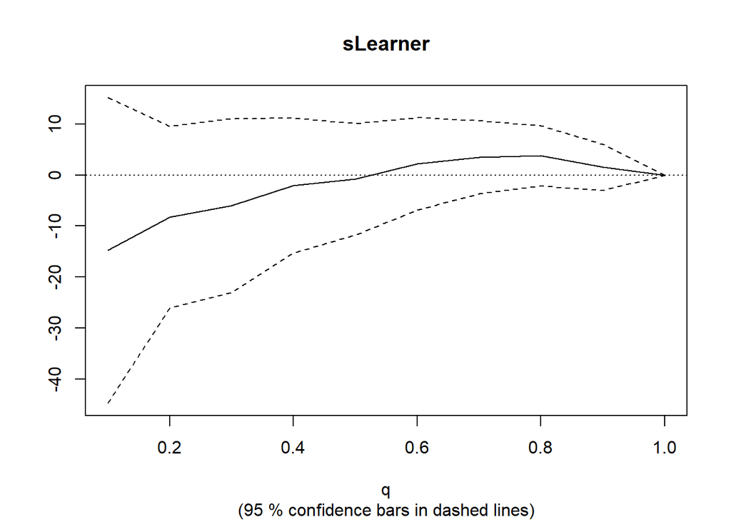

```r
cf.priority <- causal_forest(as.matrix(X_train), Y_train, W_train)
priority.cate <- predict(cf.priority, X_test)$predictions
cf.eval <- causal_forest(X_test, Y_test, W_test)

rate1 <- rank_average_treatment_effect(cf.eval, preds.sf, target = "QINI")
rate2 <- rank_average_treatment_effect(cf.eval, preds.tf, target = "QINI")
rate3 <- rank_average_treatment_effect(cf.eval, preds.xf, target = "QINI")
rate4 <- rank_average_treatment_effect(cf.eval, preds.cf, target = "QINI")

plot(rate1, main = "sLearner")
```

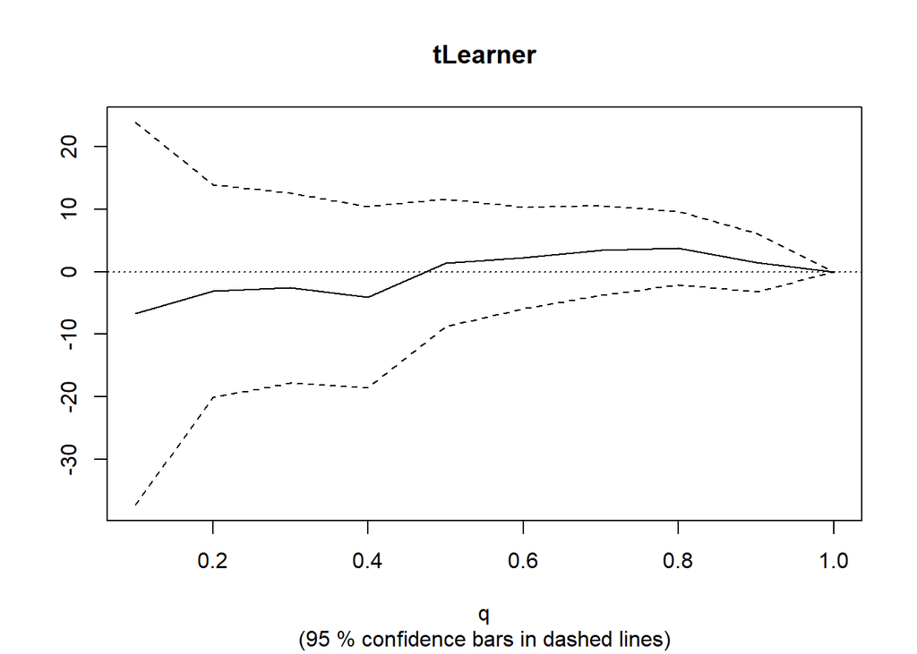

```r
plot(rate2, main = "tLearner")
```

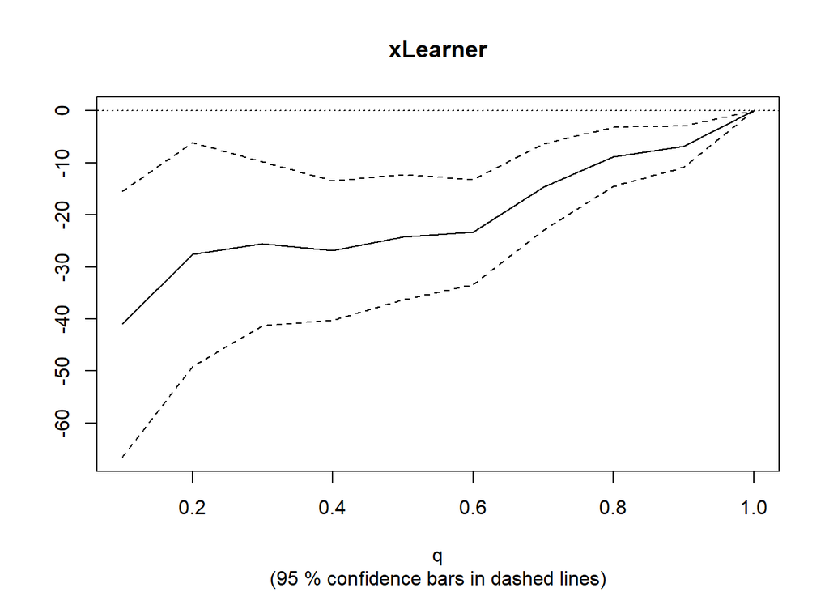

```r
plot(rate3, main = "xLearner")
```

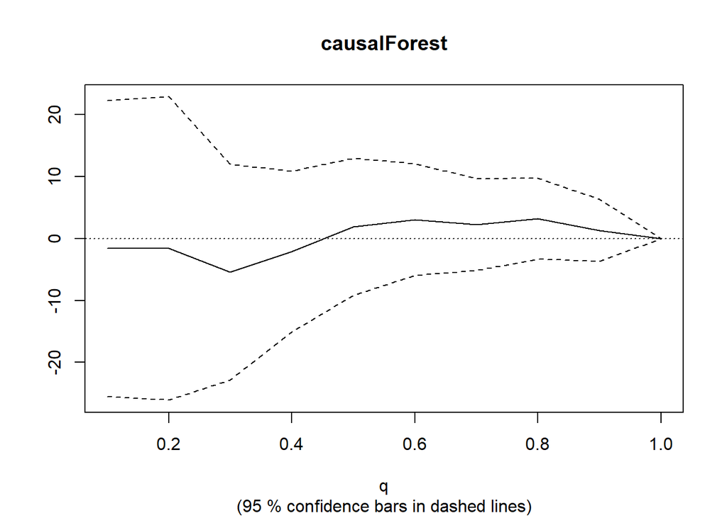

```r
plot(rate4, main = "causalForest")
```

## Part II-2

### 2a. Draw a Random Subset of 400 Observations Using All Methods

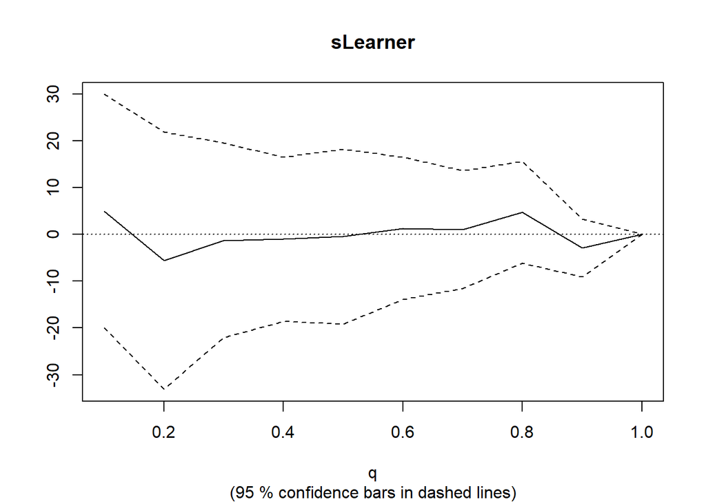

```r
set.seed(666)
star2 <- star[sample(400), ]
ind <- sample(nrow(star2), 0.7*nrow(star2))
training <- star2[ind, ]
testing <- star2[-ind, ]

W_train <- training[, treatment]
W_train <- unlist(W_train)
Y_train <- training[, outcome]
Y_train <- unlist(Y_train)
X_train <- model.matrix(fmla, training)

W_test <- testing[, treatment]
W_test <- unlist(W_test)
Y_test <- testing[, outcome]
Y_test <- unlist(Y_test)
X_test <- model.matrix(fmla, testing)


preds.sf <- sLearner(X_train, W_train, Y_train, X_test)
preds.tf <- tLearner(X_train, W_train, Y_train, X_test)
preds.xf <- xLearner(X_train, W_train, Y_train, X_test, W_test)
preds.cf <- causalForest(X_train, W_train, Y_train, X_test)

cf.eval <- causal_forest(X_test, Y_test, W_test)
rate1 <- rank_average_treatment_effect(cf.eval, preds.sf, target = "QINI")
rate2 <- rank_average_treatment_effect(cf.eval, preds.tf, target = "QINI")
rate3 <- rank_average_treatment_effect(cf.eval, preds.xf, target = "QINI")
rate4 <- rank_average_treatment_effect(cf.eval, preds.cf, target = "QINI")

plot(rate1, main = "sLearner")
```

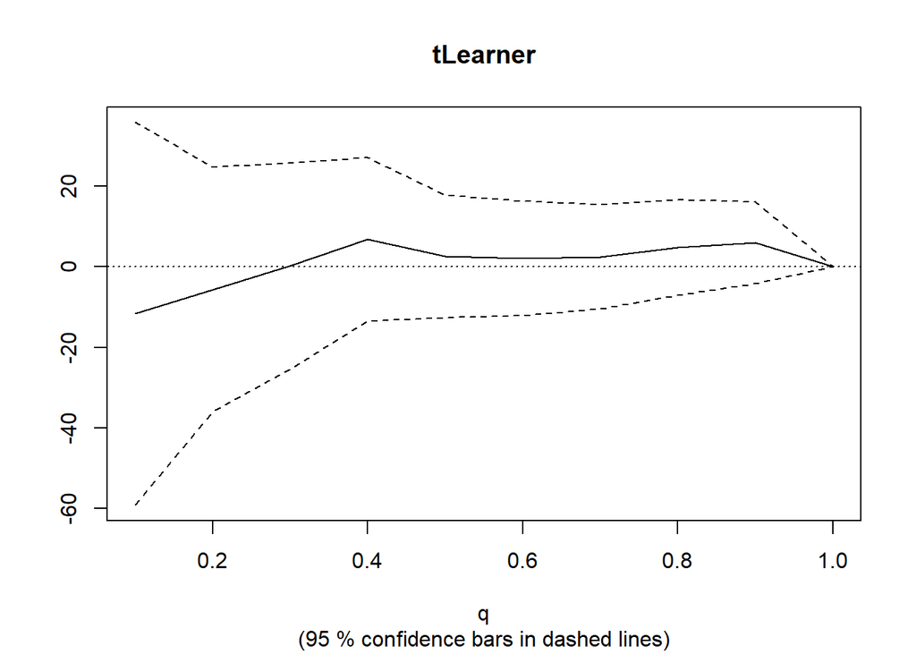

```r
plot(rate2, main = "tLearner")
```

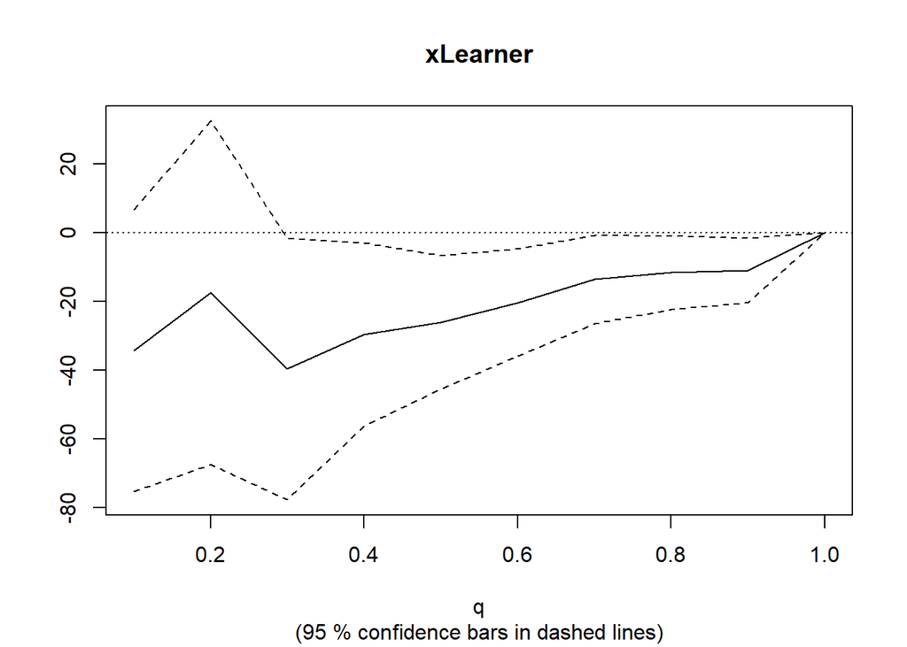

```r
plot(rate3, main = "xLearner")
```

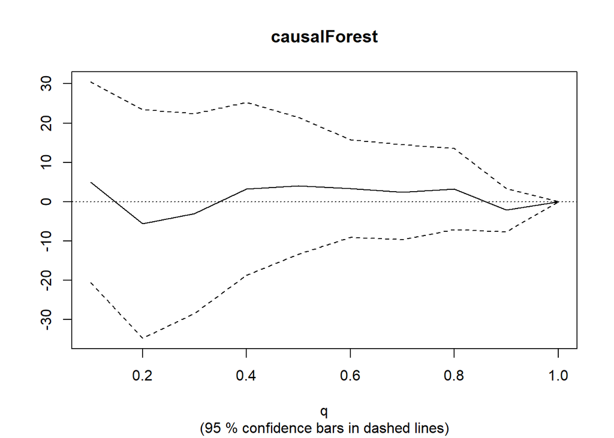

```r
plot(rate4, main = "causalForest")
```

### 2b. Draw Exactly the Same Number of Treated and Control Units

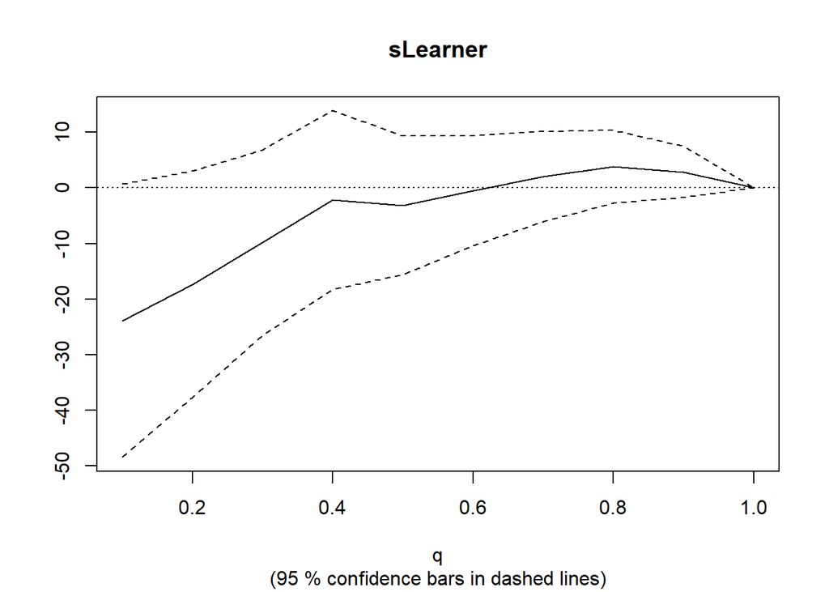

```r
set.seed(293)

star_t <- star_t[sample(nrow(star_t), 375), ]
star_c <- star_c[sample(nrow(star_c), 375), ]
star3 <- rbind(star_t, star_c)

ind <- sample(nrow(star3), 0.7*nrow(star3))
training <- star3[ind, ]
testing <- star3[-ind, ]

W_train <- training[, treatment]
W_train <- unlist(W_train)
Y_train <- training[, outcome]
Y_train <- unlist(Y_train)
X_train <- model.matrix(fmla, training)

W_test <- testing[, treatment]
W_test <- unlist(W_test)
Y_test <- testing[, outcome]
Y_test <- unlist(Y_test)
X_test <- model.matrix(fmla, testing)

preds.sf <- sLearner(X_train, W_train, Y_train, X_test)
preds.tf <- tLearner(X_train, W_train, Y_train, X_test)
preds.xf <- xLearner(X_train, W_train, Y_train, X_test, W_test)
preds.cf <- causalForest(X_train, W_train, Y_train, X_test)

cf.eval <- causal_forest(X_test, Y_test, W_test)
rate1 <- rank_average_treatment_effect(cf.eval, preds.sf, target = "QINI")
rate2 <- rank_average_treatment_effect(cf.eval, preds.tf, target = "QINI")
rate3 <- rank_average_treatment_effect(cf.eval, preds.xf, target = "QINI")
rate4 <- rank_average_treatment_effect(cf.eval, preds.cf, target = "QINI")

plot(rate1, main = "sLearner")
```

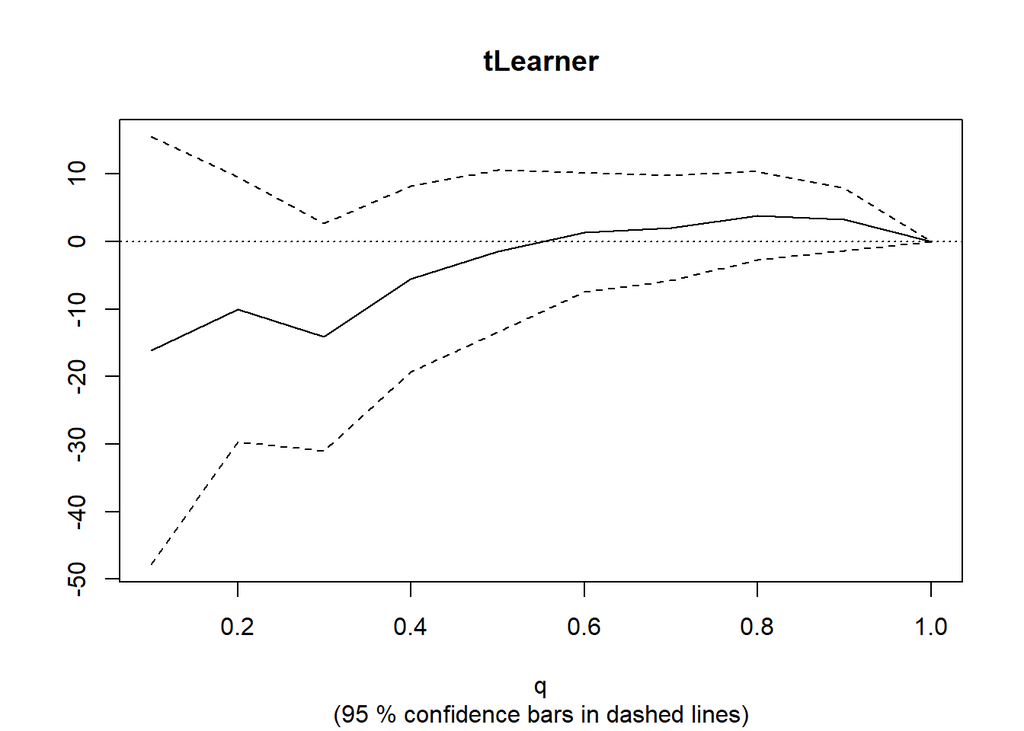

```r
plot(rate2, main = "tLearner")
```

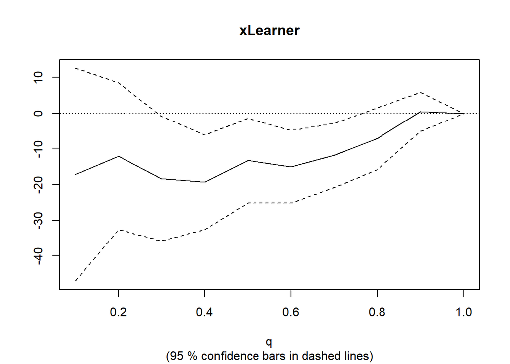

```r
plot(rate3, main = "xLearner")
```

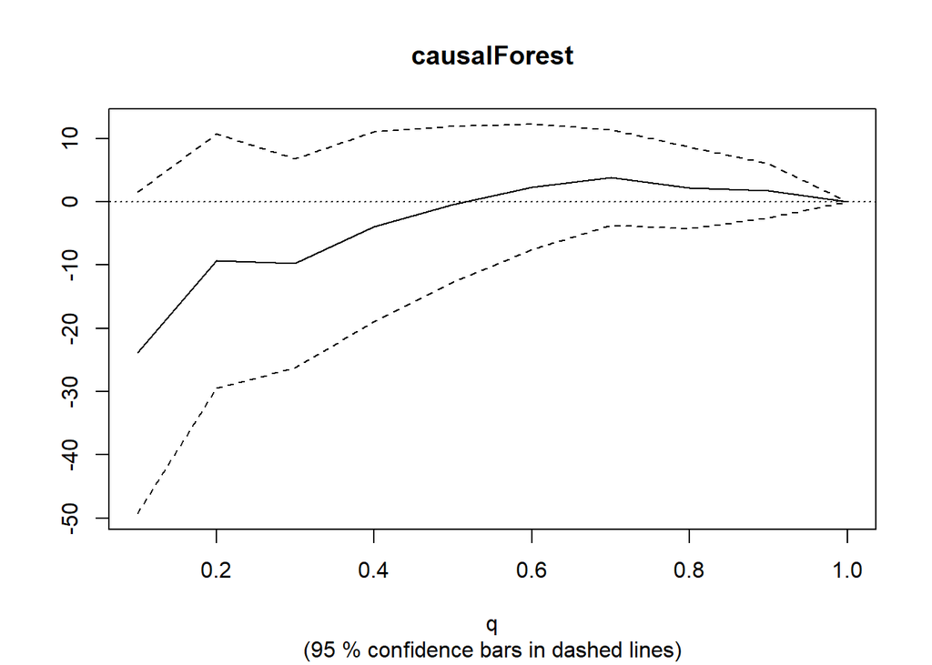

```r
plot(rate4, main = "causalForest")
```

### 2c 1.5x more control units than treated units

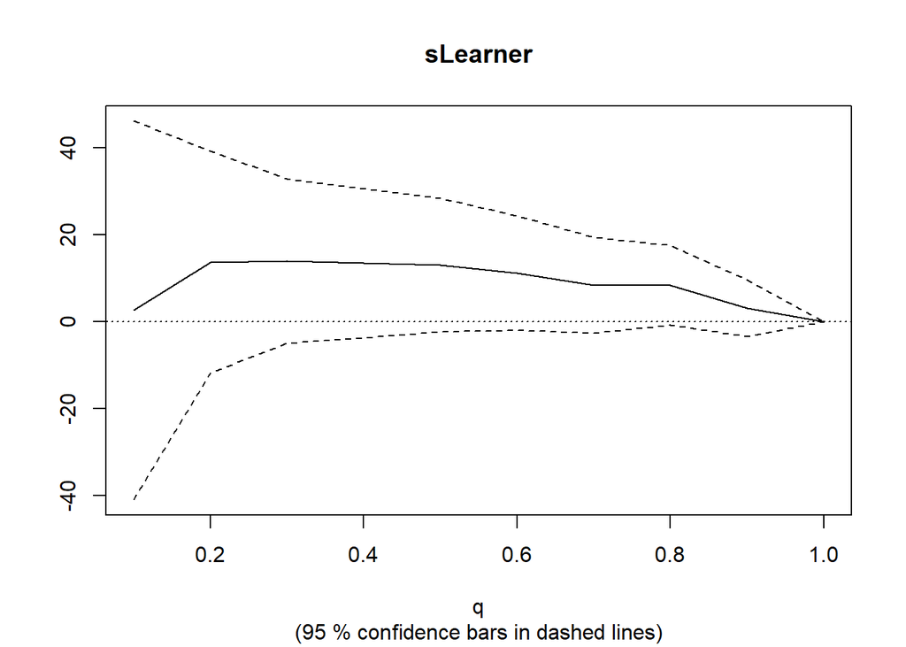

```r
set.seed(666)

star_t_2 <- star_t[sample(nrow(star_t), 250), ]
star_c_2 <- star_c[sample(nrow(star_c), 375), ]
star4 <- rbind(star_t_2, star_c_2)

ind <- sample(nrow(star4), 0.7*nrow(star3))
training <- star4[ind, ]
testing <- star4[-ind, ]


W_train <- training[, treatment]
W_train <- unlist(W_train)
Y_train <- training[, outcome]
Y_train <- unlist(Y_train)
X_train <- model.matrix(fmla, training)

W_test <- testing[, treatment]
W_test <- unlist(W_test)
Y_test <- testing[, outcome]
Y_test <- unlist(Y_test)
X_test <- model.matrix(fmla, testing)

preds.sf <- sLearner(X_train, W_train, Y_train, X_test)
preds.tf <- tLearner(X_train, W_train, Y_train, X_test)
preds.xf <- xLearner(X_train, W_train, Y_train, X_test, W_test)
preds.cf <- causalForest(X_train, W_train, Y_train, X_test)

cf.eval <- causal_forest(X_test, Y_test, W_test)
rate1 <- rank_average_treatment_effect(cf.eval, preds.sf, target = "QINI")
rate2 <- rank_average_treatment_effect(cf.eval, preds.tf, target = "QINI")
rate3 <- rank_average_treatment_effect(cf.eval, preds.xf, target = "QINI")
rate4 <- rank_average_treatment_effect(cf.eval, preds.cf, target = "QINI")

plot(rate1, main = "sLearner")
```

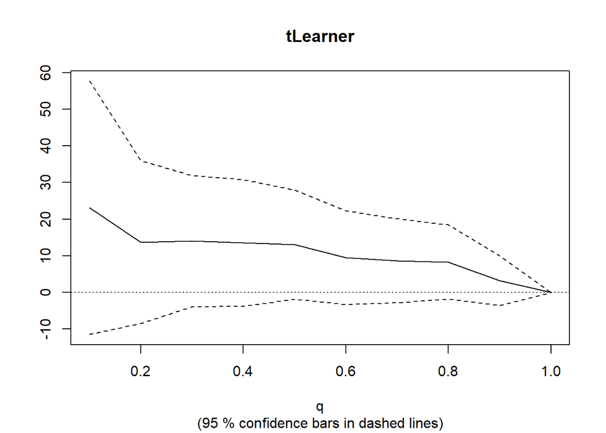

```r
plot(rate2, main = "tLearner")
```

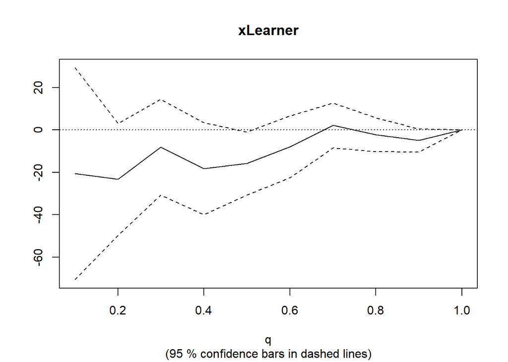

```r
plot(rate3, main = "xLearner")
```

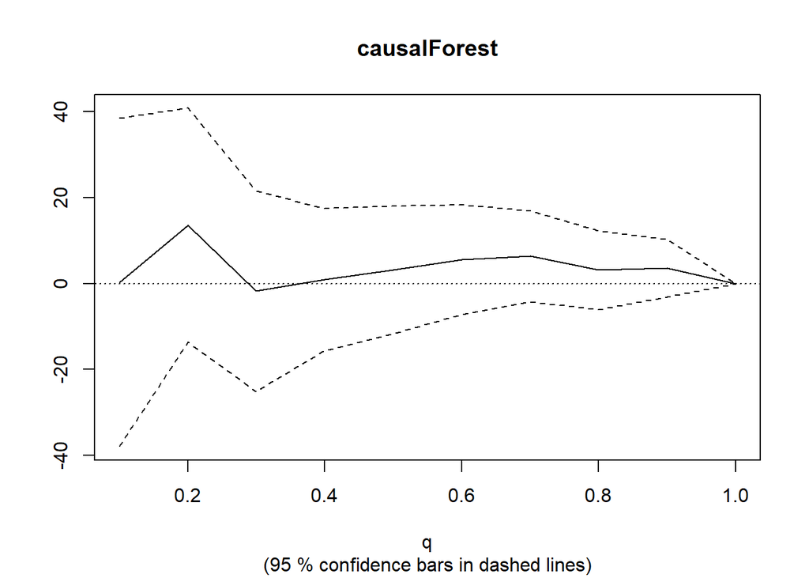

```r
plot(rate4, main = "causalForest")
```